# Notas: Introducción a la Biología de Sistemas

Jorge Luis Gómez

03 February, 2022

# 1 Repaso de redes Booleanas

With network definition we can establish that it is a system interconnected nodes, that communicate and may interact with each other at times. We need a group and interaction for networks to exist. Networks may work connecting computers, proteins, people, etc. We have the vertex/nodes and the connections/edges $G=(V,E)$. The groups will be conformed by the nodes, while the edeges will make up the connections within said groups. We may have different types of individuals in each group and their relation within and among themselves can be of a varied range of classes. We must try to learn the nature of the connections of each node.

Networks are ever growing in their applications and the fashion in which they are used for a myriad of subjects. At first, it was first know as graph theory what now is the network science, maturing from the mathematical fields as well as the computational field nowadays. We may find synonyms as nodes/vertex, links/edges and graphs/networks; they may be interchangeable but do have differences in certain aspects when speaking very specifically.

We can represent the networks via the use of an adjacency matrix, with 1’s and 0’s that represent either a connection or its absence.

## 1.1 Boolean networks

They are called Boolean because it is based on the Boolean algebra with truth tables and Boolean operators. We create the truth tables based on the Boolean rules we have set for our network. Based om the rules and the truth tables we may find attractors. We have to define the regulatory network model, recover dynamical behavior, explain the attractors, find new ones and demonstrate. We add a set of update rules, meaning we can update certain nodes with each time step in the network based on the state of other nodes and watch transitions through the time. The experimentally grounded network constitutes a regulatory mechanism driving the specification of the experimentally proved cellular phenotypes. We transform biology to a binary system.We can describe the boolean networks as follows $x_i(t + 1)= F_i(x_1(t),x_2(t),...x_n(t)), i=1,...,n$ . It changes with time, but we’re interested in times when it doesn’t change anymore, meaning the attractors.

### 1.1.1 Components

1. A list of genes hypothesized to summarize the properties of interest in a developmental system and a prediction of how those properties change over time. The list of chosen genes define the state of the system.
2. A set of updating rules specifying in terms of logical propositions how the activity of each gene changes over time as a function of the current activity of all the involved genes. Thus, the updating rules fix the system’s transitions.

### 1.1.2 Paradigms

There are three paradigms for Boolean networks. Synchronous, Asynchronous, and Probabilistic. When referring to synchronous, the rules are updated at each step based on the conditions of all the nodes in the previous state. Asynchronous means some update at different rates, so that some are updated with the rules, but others are not; it can represent speed or perpetuity of expression of certain genes or a threshold that needs to be covered before inhibition or activation. It is more realistic but requires deeper understanding and knowledge of the network. Finally, probabilistic updates mean we have more than a given set of update rules for each node; we can have many rules for each node and we assign a probability of following each set of rules.

The three of them are useful in many ways, but they still have disadvantages. We must strive for an adequate balance of realism and a descriptive model. We have to start from an easier system and work towards a more complex system, if need be. We have to select the information and approach for what we’re trying to answer.

The attractor basin is the sum of all states that end with the attractor. For synchronous rules, the basin of attraction is defined by different states, meaning a state only represents one attractor, as it will only end in such a result. With asynchronous rules, the states may share different attractors and cannot be as easily detected. Different probabilities of states is observable in synchronous updates.

### 1.1.4 Exercises BoolNet

`Boolnet` can be used for the use of the paradigms we previously discussed. In the header of the text file we need we must have at least:

targets, factors

And can be used also with probabilities:

targets, factors, probabilities

For this purpose we can write the networks in a text editor and then load it with the function `loadNetwork()` or write it directly with artifacts as follows.

```r
library(BoolNet)

net_1 <- loadNetwork("network_ex_1")

net_1
```

```
## Boolean network with 4 genes
##
## Involved genes:
## Gene1 Gene2 Gene3 Gene4
##
## Transition functions:
## Gene1 = !Gene2 | !Gene3
## Gene2 = Gene3 & Gene4
## Gene3 = Gene2 & !Gene1
## Gene4 = 1
##
## Knocked-out and over-expressed genes:
## Gene4 = 1
```

```r
# Make it in R
#sink("testNet.bn") name and address it will be created
#cat("targets, factors\n")
#cat("Gene1, !Gene2 | !Gene3\n")
#cat("Gene2, Gene3 & Gene4\n")
#cat("Gene3, Gene2 & !Gene1\n")
#cat("Gene4, 1\n") #over-expression
#sink()
```

We can have over-expressed genes that are always active or knocked-out that will not express no matter what. (1’s and 0’s respectively)

**1. Exercise with real network**

```r
net_2 <- loadNetwork("red_real_ex") # apparently it doesn't accept "-" i the gene names, wonder if it can accept with "." or any kind of notation
getAttractors(net_2)
```

```
## Attractor 1 is a simple attractor consisting of 1 state(s) and has a basin of 393216 state(s):
##
##  |--<----------------------|
##  V                         |
##  00100101000100010100010   |
##  V                         |
##  |-->----------------------|
##
##
## Genes are encoded in the following order: IFNBR IFNG GATA3 IL12 IFNB IL10R IRAK IL4R NFAT SOCS1 IL18R IL4 TCR IL12R Tbet STAT6 STAT4 STAT3 STAT1 JAK1 IFNGR IL10 IL18
##
## Attractor 2 is a simple attractor consisting of 1 state(s) and has a basin of 131072 state(s):
##
##  |--<----------------------|
##  V                         |
##  01000000010000100000100   |
##  V                         |
##  |-->----------------------|
##
##
## Genes are encoded in the following order: IFNBR IFNG GATA3 IL12 IFNB IL10R IRAK IL4R NFAT SOCS1 IL18R IL4 TCR IL12R Tbet STAT6 STAT4 STAT3 STAT1 JAK1 IFNGR IL10 IL18
```

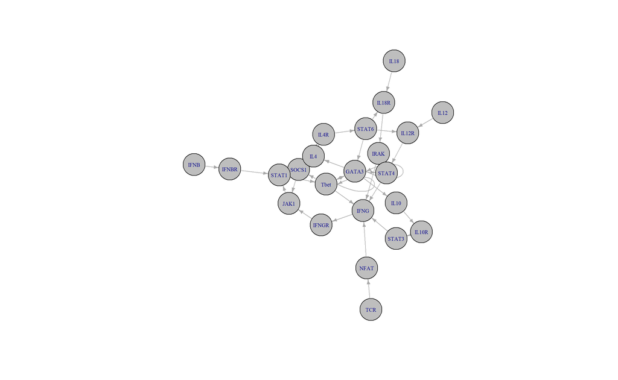

```r
plotNetworkWiring(net_2)
```

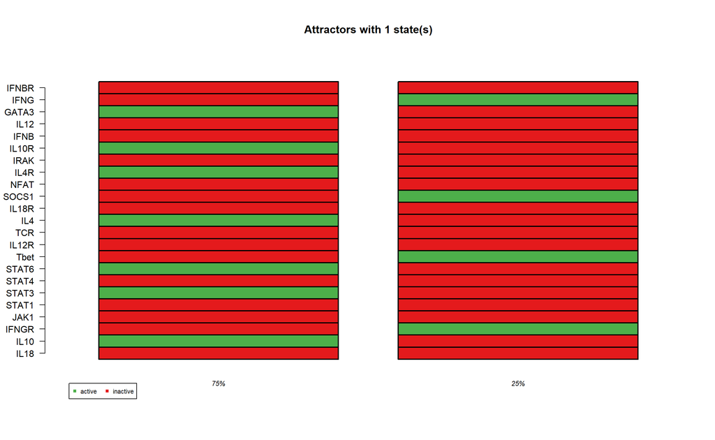

```
## $`1`
##       Attr1.1 Attr2.1
## IFNBR       0       0
## IFNG        0       1
## GATA3       1       0
## IL12        0       0
## IFNB        0       0
## IL10R       1       0
## IRAK        0       0
## IL4R        1       0
## NFAT        0       0
## SOCS1       0       1
## IL18R       0       0
## IL4         1       0
## TCR         0       0
## IL12R       0       0
## Tbet        0       1
## STAT6       1       0
## STAT4       0       0
## STAT3       1       0
## STAT1       0       0
## JAK1        0       0
## IFNGR       0       1
## IL10        1       0
## IL18        0       0
```

```r
plotAttractors(getAttractors(net_2))
```

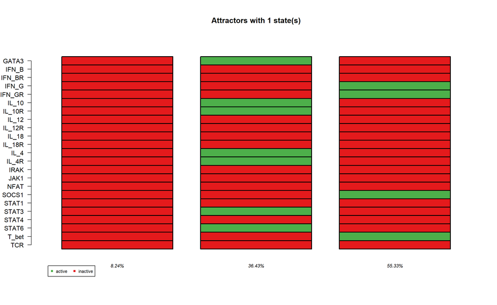

```
## $`1`
##        Attr1.1 Attr2.1 Attr3.1
## GATA3        0       1       0
## IFN_B        0       0       0
## IFN_BR       0       0       0
## IFN_G        0       0       1
## IFN_GR       0       0       1
## IL_10        0       1       0
## IL_10R       0       1       0
## IL_12        0       0       0
## IL_12R       0       0       0
## IL_18        0       0       0
## IL_18R       0       0       0
## IL_4         0       1       0
## IL_4R        0       1       0
## IRAK         0       0       0
## JAK1         0       0       0
## NFAT         0       0       0
## SOCS1        0       0       1
## STAT1        0       0       0
## STAT3        0       1       0
## STAT4        0       0       0
## STAT6        0       1       0
## T_bet        0       0       1
## TCR          0       0       0
```

```r
# getTransitionTable(getAttractors(net_2)) do not run, it takes time
# getBasinOfAttraction(getAttractors(net_2),1) same problem

net_3 <- loadNetwork("real_ex_2") # check differences with previous set of rules
plotAttractors(getAttractors(net_3))
```

There is a not so successful repository for systems biology known as SBML. We can access in order to download or upload data for us to work. It stands for Systems Biology Markup Language. We work with a certain language for it to be homogeneous; we can download a model from there with the help of `BoolNet`. We go to BioModels and can find different types of models, from ordinary differentiation equations to logical models.

```r
# net_4 <- loadSBML("RodriguezJorge_Merged_TCR_TLR5_Signalling_BooleanModel_15Jul2018.sbml") # missing info

net_4 <- loadSBML("MODEL1610060001_url.xml")
```

**Excercises**

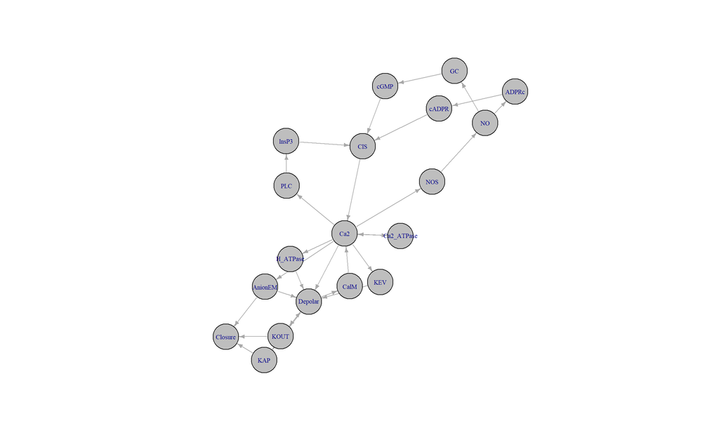

```r
ex_1 <- loadNetwork("red_ex_1")
plotNetworkWiring(ex_1)
```

```r
getAttractors(ex_1)
```

```
## Attractor 1 is a simple attractor consisting of 4 state(s) and has a basin of 524288 state(s):
##
##  |--<------------------|
##  V                     |
##  1110001011111011000   |
##  1001001110111011001   |
##  1001110100000101111   |
##  1110110001000101110   |
##  V                     |
##  |-->------------------|
##
##
## Genes are encoded in the following order: CIS cGMP cADPR InsP3 GC ADPRc PLC NO NOS Ca2 Ca2_ATPase CalM KEV H_ATPase AnionEM Closure KOUT KAP Depolar
```

1. Is the network strongly connected? Explain your answer. $n(n-1)/2$ is the max number of connections for a non-directed network. In the case of directed networks it is $n(n-1)$. We the compare our connections with the maximum. Density $D= \frac{edges}{Total}$, we get the percentage and can evaluate.
2. If the network is not strongly connected, identify its strongly connected components.
3. Does the network contain loops? If so, identify them. Yes, as seen with this work `getAttractors(ex_1)`.
4. Does the network contain cycles? If so, identify all cycles.
5. Are there any feed-forward loops? If so, identify them as positive, negative, or incoherent.
6. Are there any feedback loops? Identify them. Identify their sign as positive or negative.

Loops vs. cycles: cycle follows directions and will take you to the starting point. In loops we cannot follow the direction and arrive at the starting point. Coherent loops regulate directly and indirectly in the same fashion the nodes, while an incoherent loops regulates with different “sign” the nodes.

# 2 History and basis of Boolean networks

Stuart Kauffman is Boolean network’s father, the baseline for work. He was the one who proposed the idea of Boolean networks in 1969, he was initially a medic and had interest for many disciplines. Important works from this man include “The Origin of Order”. He wanted to understand cellular differentiation, understand how the specialization from cells work from a common base that all cells share. He proposed a network in which activation and inhibition of different genes may yield different phenotypes. Due to lack of knowledge available at his time, he proposed that the network’s connections were random, but we know that it isn’t the case.

Elena Álvarez and Luis Mendoza applied for the first time the idea of obtaining attractors from a network of *Arabidopsis thaliana*, where they discovered that phenotypes matched with those predicted by their network. They demosntrated their model approached both things that were already known, and possibilities that were unknown. More detailed networks then were created and the precision started to grew with perturbations applied to the networks.

Reka Albert and Barabasi were later on pillars of this models. Both have generated ideas and works that attractors obtained from the models are in accordance with phenotypes observed in nature. The idea is making models that can be as useful or more than the experiments by themselves.

# 3 Perturbation

We change the state given to our system, meaning the activation or inhibition of the network; we do not change the update rules. We compare the next states from the original state and from the one we perturbed. The idea is we construct given the perturbation, how it affects the behavior. We may have three outcomes, the perturbation amplifies, we get into the same outcome as the original or we destroy/kill the perturbation. We check for differences and compare. We get the total “sum” of differences form the original compared with the one with perturbation; if after a long time the difference is 0, it means it will get to the same state no matter what, but if there is difference, it means the perturbation is actually affecting the outcome. We make the comparisons after a long enough period of time, we may see if it yields different attractors or not. $\frac{1}{n}\sum_{i=1}^{n}|\sigma_n(t)-\hat{\sigma}_n(t)|$

# 4 Ginsim

First of all, we need to download ginsim and have Javascript downloaded beforehand.

# 5

#### 5.0.0.1 Useful arguments

There also are some operators that can be quite useful that are not as usual as AND, OR, and NOT.

1. When we want many things to be true as a sequence of *&*, we may use `all(gene1, gene2, ...)`
2. The operator `any()` will execute if any of the rules comply.
3. `maj()` is used when the majority of rules do comply.
4. `sumlt()` we can make it as follow `sumlt(gen1,gen2,...gen7, 3)` will evaluate as true if at least the number of genes we stipulate as the final number in the rules do comply. In the example it will evaluate if at least 3 genes are True.

BoolNet, Antelope, ginsim, gnbox, gna, biocham

# 6 Ideas

Checar por si quitar aparentes redundancias puede evitar más gasto de recursos pero mantener estructuras de las redes clusters. Machine leraning para ver si se puede hacer update de las reglas